# Interplay of Text, Reader And Context (InTRACt) in children’s digital reading comprehension: Preregistration

# Abstract

Children’s reading comprehension involves the interplay of three dimensions: the text (its lexical, syntactic, and discourse characteristics), the reader (age, developing cognitive capacity), and the reading context (the digital medium, the availability of supportive features such as narration, and the child’s linguistic environment). Despite substantial laboratory-based progress in characterising each dimension in isolation, their joint influence under naturalistic conditions — and how it changes across the 7–10 age range — is poorly understood. The present preregistration describes the InTRACt study, which addresses this gap by analysing large-scale behavioural logs from *Let’s Story*, an AI-powered storytelling feature of the *Applaydu* edutainment app deployed across more than 40 countries and 19 languages. Reading time per word and in-app quiz accuracy are the primary and secondary outcomes, respectively. For each story, a broad range of computational text features will be extracted and reduced to principal components before model entry. Reader age is treated as a continuous moderator of text-feature effects, capturing the developmental trajectory of sensitivity to linguistic complexity. Contextual factors — in particular, whether AI read-aloud narration was enabled — are examined as a further moderator, expected to benefit younger, less fluent readers most. All confirmatory analyses use Bayesian multilevel models with random effects for child and language. Five hypotheses are pre-registered: that syntactic and lexical complexity slow reading while discourse coherence accelerates it; that syntactic complexity effects diminish with age as working memory capacity develops; that coherence benefits are largest for younger readers with weaker inference skills; that narration advantages are greatest for younger children still acquiring decoding fluency; and that reading speed correlates positively with comprehension accuracy.

# 1 Background

## 1.1 Text-Level Predictors of Reading Comprehension

A longstanding tradition in computational psycholinguistics explains reading comprehension in terms of measurable text and reader variables. This body of work identifies specific linguistic features, operating at the lexical, syntactic and discourse levels, that predict how readers engage with and understand text.

At the lexical level, word frequency is among the most reliable predictors of reading behaviour. High-frequency words are recognised faster and fixated for shorter durations than low-frequency words, a pattern replicated across dozens of eye-tracking studies and remarkably consistent across languages and orthographies (e.g., Mézière et al., 2023; Norman et al., 2025). In children, frequency effects tend to be larger than in adults, reflecting the less automatised nature of early lexical access (Hsiao & Nation, 2018). Frequency norms derived from subtitle corpora (e.g., the Subtitle Lexical Frequencies [SUBTLEX] databases), including SUBTLEX-UK for British English (van Heuven et al., 2014), have become standard tools for operationalising this variable, offering estimates that closely approximate everyday language exposure across multiple languages (Brysbaert et al., 2019). More recently, resources such as the Children and Young People’s Books Lexicon (CYP-LEX) — derived from over 1,200 books read by children and young people in the United Kingdom — offer a more ecologically valid frequency baseline for studies of developing readers, capturing the vocabulary children actually encounter in their reading environment (Korochkina et al., 2024). A related lexical property, word concreteness, also shapes comprehension: concrete, highly imageable words (e.g., *apple*, *river*) are processed more quickly and remembered better than abstract words (e.g., *justice*, *theory*) (Magnabosco & Hauk, 2024). This concreteness advantage, often attributed to dual-coding accounts in which concrete words activate both verbal and imagistic representations (Bernabeu, 2022; Kaup et al., 2025), is especially pronounced in younger readers and second-language learners, who rely more heavily on grounded, sensory representations to construct situation models from text — bridging gaps in background knowledge through the ease with which words evoke mental imagery (Muraki et al., 2025). Consistent with this, Pickren et al. (2022) demonstrated that text characteristics including word emotionality and concreteness predict significant unique variance in reading performance among elementary school children, above and beyond traditional readability metrics. A third lexical variable, the diversity of vocabulary within a text — operationalised through indices such as the type/token ratio (TTR) or the Measure of Textual Lexical Diversity (MTLD) — modulates reading difficulty in a manner that depends on the reader’s own vocabulary knowledge (Fredrick & Craven, 2025). For skilled adults, moderate lexical diversity may sustain engagement through varied and precise word choice; for less proficient readers, including children, high diversity can overwhelm decoding resources and impair comprehension (Cain & Oakhill, 2014; Van Den Bosch et al., 2019).

At the syntactic level, sentence structure exerts its own demands on the reader. Measures such as mean dependency distance (the average linear distance between syntactically related words), the number of embedded clauses and subordination ratios all capture aspects of structural complexity that predict reading difficulty (Nielsen et al., 2025). Longer dependency distances, in particular, impose greater working memory demands, as readers must maintain information across intervening material before resolving a syntactic relationship. Because children’s working memory capacity is still developing, they are disproportionately affected by syntactic complexity — including the processing burden imposed by long-distance dependencies and complex noun phrase structures — relative to adults (I. Chang, 2020; Cui et al., 2024; Delage & Frauenfelder, 2019), a developmental asymmetry that is central to several of the hypotheses we test in this study. Converging evidence comes from Marjokorpi & van Rijt (2025), who found that explicit grammatical understanding was a robust predictor of reading comprehension in secondary-school students even after controlling for socioeconomic background, writing ability, and other literacy-related factors — underscoring that sensitivity to syntactic structure continues to underlie comprehension development well into adolescence.

Beyond words and sentences, the coherence of a text, the degree to which successive ideas are logically and semantically connected, is central to comprehension. Computational measures of coherence, including latent semantic analysis (LSA)-based sentence-to-sentence similarity, co-reference overlap and connective density, index the ease with which readers can integrate information across a passage (Crossley et al., 2019). Highly coherent texts reduce the inferential burden and are generally associated with better comprehension, particularly for readers with lower prior knowledge (Hattan & Kendeou, 2024). Complementing these deeper semantic relations are surface-level cohesion signals: explicit connectives such as *because*, *however* and *therefore* that mark the logical structure of a text. Automated tools such as Coh-Metrix (Graesser et al., 2014) now make it possible to compute many coherence and cohesion indices at once, enabling large-scale analyses of text difficulty that would be impractical to conduct by hand (Crossley, 2025).

These individual variables have also been combined into composite indices of text difficulty. Classical readability formulae (e.g., Flesch–Kincaid, Dale–Chall) aggregate surface features such as word length and sentence length into single scores, and although they are limited in linguistic sophistication, they remain widely used in educational and applied contexts (Crossley et al., 2023; Wang et al., 2024). More recent multi-dimensional frameworks integrate frequency, concreteness, syntactic complexity and coherence into richer characterisations of what makes a text difficult and for whom, moving beyond simple heuristics toward discourse-level representations (Crossley et al., 2023; Crossley, 2025; Goldman, 2024; Li et al., 2025; Wang et al., 2024).

Taken together, this body of research establishes that reading comprehension is jointly shaped by many text-level variables operating across multiple linguistic levels (Duff & Brydon, 2020; Nation, 2019). These variables predict reading behaviour — including reading time, fixation patterns and comprehension accuracy — in both children and adults, though with developmental differences in magnitude and direction. The present study builds on this tradition by incorporating these established predictors as fixed effects in our analytic models (see Analytic Plan), while also examining how they interact with child age as a proxy for developing linguistic and cognitive capacity. We turn next to a more recent line of work that complements these feature-based approaches with neural language models.

## 1.2 Computational Modelling of Reading With Neural Language Models

While the text-level features reviewed above offer interpretable, theory-driven predictors of reading behaviour, a parallel line of research has begun to ask whether the representations learned by neural language models can capture the same reading phenomena — and potentially go beyond what hand-crafted features achieve. This approach treats the internal states of large language models (LLMs) as proxies for the representations that the human language system constructs during reading, and evaluates their fit to behavioural and neural data.

In adults, evidence for this approach has accumulated rapidly. Hahn & Keller (2023) introduced a neural attention model that adapts its processing to task demands, replicating adult eye-movement patterns (fixation durations, skip rates) across different reading goals within a single architecture — providing evidence that task-specific reading strategies can be modelled as optimal attentional adaptations rather than requiring separate mechanisms. Hosseini et al. (2024) demonstrated that GPT-2–style language models trained on a developmentally plausible corpus (~100M words) could predict adult functional magnetic resonance imaging (fMRI) responses to sentences with near-maximal fidelity, with performance saturating after moderate training data. Together, these findings suggest that adult reading is largely driven by core linguistic mechanisms — word predictability, sequential dependency processing — that current LLMs capture with considerable accuracy.

Extending this work to child readers presents both opportunities and challenges. Monaghan (2023) reviews how computational models originally developed for adult word reading have been adapted to simulate literacy acquisition in children, tracing the developing connections between orthography, phonology and semantics across languages. Empirical work has begun to complement these simulations with large-scale behavioural data. Sortkær et al. (2021), for instance, analysed logs from approximately 48,000 Danish schoolchildren using a reading app (BookBites) and found a moderate positive correlation (*r* ≈ 0.4) between app-derived reading speed and standardised reading test scores — indicating that computational metrics extracted from naturalistic digital reading can meaningfully index developing literacy. More recently, large-scale eye-tracking benchmarks such as OneStop (Berzak et al., 2025) have linked gaze patterns to reading comprehension, opening the door to models that predict individual comprehension from rich behavioural signals.

Systematic reviews of the applied landscape further contextualise these developments. Booton et al. (2023) found that among e-book app features, in-built narration (read-aloud) substantially improves pre-readers’ story comprehension and vocabulary, whereas unrelated interactive “game” elements provide no measurable benefit. Chuang & Jamiat (2023) reached a similar conclusion after reviewing 50 studies of interactive children’s books: supportive multimedia features (animations, contextual glossaries) enhance emergent literacy, while distracting game elements can actively impede reading outcomes. These findings highlight that the medium through which children encounter text matters — a consideration that is central to the present study’s design.

In sum, neural language models complement the traditional text-feature approach: where hand-crafted variables capture well-understood sources of variation, model-derived measures may capture subtler distributional and contextual regularities (Seidenberg & MacDonald, 2018). However, for child readers, the evidence base is thinner, and many of the traditional text-level variables (frequency, coherence, syntactic complexity) may still be the most informative predictors. Our study is positioned at this intersection, using both established linguistic features and a model-derived index of word predictability (surprisal) to predict children’s reading behaviour across the 7–10 age range. Table 1 summarises the key studies from both traditions that inform our hypotheses.

Table 1: Representative computational-reading studies by age group

[output not shown]

## 1.3 App-Based Data in Reading Research

Although digital reading platforms can provide detailed behavioural data (Altamura et al., 2025; Furenes et al., 2021), few computational studies have used app-generated logs as a window into reading processes. The work that does exist falls broadly into two categories, which differ in their origins and scientific utility.

The first category comprises research and educational apps — platforms designed with learning objectives and, often, data collection in mind. Sortkær et al. (2021) exemplifies this approach: by analysing reading logs from BookBites, a classroom-deployed app, they demonstrated that passively recorded reading speed correlated meaningfully with standardised reading ability. Such studies establish the principle that app logs can reflect underlying cognitive processes, but they typically operate within controlled educational settings and with relatively constrained populations.

The second category — commercial ‘edutainment’ apps — is far less explored in the academic literature, despite its vastly larger user base. These apps combine entertainment with incidental learning goals, and their data are generated under naturalistic, unconstrained conditions. A case in point is *Let’s Story*, an artificial intelligence (AI)-powered digital storytelling feature embedded within *Applaydu* — an edutainment app developed by Gameloft and Ferrero International — which enables families to co-create storybooks using Microsoft’s generative AI tools across 19 languages and passively records each child’s reading time and in-app quiz performance (Ratner et al., 2025). Children select from a menu of story elements (plot, setting, character and theme), and the app generates a unique narrative that is then read aloud by an AI narrator in the family’s chosen language. To our knowledge, no previous study has yet analysed data from Applaydu or any comparable commercial edutainment platform at scale through the lens of computational psycholinguistics. The existing literature on reading apps instead consists primarily of reviews and small-scale experiments examining specific app features. Booton et al. (2023), for example, systematically reviewed 11 studies and found that read-aloud narration aided comprehension, while extra interactive games did not. More broadly, content analyses of commercially available educational apps have raised persistent concerns about instructional quality. Furlong et al. (2025) found that the majority of phonics apps on the Australian Google Play and Apple stores failed to meet basic pedagogical criteria, with expert reviewers recommending only 27.5% of 309 apps appraised. Chatzopoulos et al. (2023) reached convergent conclusions through a rubric-based evaluation of 50 Google Play educational apps, finding that educational content was systematically the weakest dimension and that consumer star ratings showed poor correspondence with expert quality scores — a limitation that applies directly to the Applaydu platform examined in the present study.

This gap between the commercial availability of reading-app data and its scientific use is notable. Table 2 summarises the small number of relevant studies, along with their sample contexts and key findings.

Table 2: Selected studies on app-based reading data

| **Study** | **App type and sample** | **Data, focus, and key findings** |
| --- | --- | --- |
| Booton et al. (2023) | Educational e-books; children 3–11 yrs (11 studies) | App features: narration, augmented reality (AR), prompts, hotspots. Narration improved comprehension for pre-readers; AR boosted L2 vocabulary; hotspots showed no benefit. |
| Chatzopoulos et al. (2023) | General educational, Google Play; *N* = 50 apps | Rubric-based quality appraisal. Educational content was the weakest dimension; consumer ratings showed poor correspondence with expert scores. |
| Chuang & Jamiat (2023) | Edutainment/educational; 3–8 yr olds (50 studies) | Interactive book features. Multimedia enhancements yielded medium-to-large literacy gains; unrelated game features harmed focus. |
| Furlong et al. (2025) | Commercial phonics apps; *N* = 309 | Content analysis of app quality. Majority lacked structured pedagogy; only ~27% met expert criteria; consumer ratings uncorrelated with expert evaluations. |
| Sortkær et al. (2021) | Educational (BookBites); children *N* ≈ 48,000, grades 3–6 | App reading time vs. standardised test scores. Reading speed correlated with ability (*r* = .39–.48); models predicted 16–18% of variance in progress. |

The present project addresses this gap directly. By analysing large-scale multilingual behavioural logs from the *Let’s Story* feature of Applaydu, we aim to test whether the text-level variables identified in the laboratory-based literature — frequency, lexical diversity, syntactic complexity, coherence — predict children’s reading behaviour in the wild, and how their effects are moderated by child age and the availability of narration support.

These aims translate into four research questions that the confirmatory analyses address directly. The first (RQ1) concerns whether the lexical-distributional, syntactic-structural, and discourse-coherence properties of a story predict how long children spend reading each word. The second (RQ2) concerns whether the influence of syntactic and discourse properties on reading time changes across the 7–10 age range. The third (RQ3) concerns whether the availability of AI read-aloud narration moderates children’s reading behaviour, and whether that moderation itself varies with age. The fourth (RQ4) concerns whether children’s reading speed relates to their comprehension, indexed by in-app quiz accuracy. Each question maps onto one or more of the five directional hypotheses set out below, which the study design table summarises together with their statistical tests and the interpretation of possible outcomes (Table 4).

# 2 Methods

## 2.1 Participants

The study sample consists of data from the *Let’s Story* feature of *Applaydu*, a commercially deployed edutainment app developed by Gameloft and Ferrero International that offers a range of activities targeting different skills. *Let’s Story* is one such activity, enabling families to co-create AI-generated storybooks using Microsoft’s generative AI tools across more than 40 countries and 19 languages. In the first six months following its launch in late 2024, *Let’s Story* facilitated over 2.4 million story sessions and generated more than 50,000 stories (Ratner et al., 2025). We will include all children (ages 7–10) who meet the inclusion criteria below [exact *N* to be determined after data extraction] (Babayiğit et al., 2022; Lervåg & Aukrust, 2010). All data are anonymised and collected passively, with no additional experimental manipulation. Children will be included if (a) parental consent was registered in-app, (b) they were between 7 and 10 years of age as reported at registration, and (c) they completed at least 5 distinct story sessions. Sessions will be excluded if reading times fall below 2 seconds per page or exceed 5 minutes per page (indicating skipping or abandonment), if accounts are identified as duplicates via device fingerprinting, or if sessions were flagged by the app as incomplete (e.g., due to an app crash).

## 2.2 Data Provenance and Researcher Access

Because the *Let’s Story* logs were generated by ordinary app use before this Stage 1 submission, the study is a secondary analysis of pre-existing data, and we certify the research team’s level of prior access in line with the Registered Reports requirements for existing data. At the time of submission the analytic dataset has not been extracted, and no member of the team has examined any relationship between the text-feature predictors and the reading-time or comprehension outcomes; the only previously known quantities are aggregate platform statistics already in the public domain, such as the total numbers of story sessions and generated stories (Ratner et al., 2025). Data extraction, computation of text features, and model fitting will be carried out only after in-principle acceptance. To protect the confirmatory tests from analytic flexibility, text-feature construction and the dimension-reduction step (see Analytic Plan) will be performed without reference to the outcome variables, so that decisions about which features to retain cannot be influenced by their association with reading time or comprehension. Should any unanticipated prior access to the data come to light, it will be disclosed in the Stage 2 manuscript.

## 2.3 Materials

The reading materials consist of short narrative passages (200–400 words each) drawn from the *Let’s Story* library within the *Applaydu* app. These stories vary in vocabulary, syntax and coherence, providing natural variation in the text-level features of interest.

For each story, we will compute computational text features organised into four theoretically motivated families and extracted with tools that operate across the languages represented in the corpus. Morphosyntactic annotation — tokenisation, lemmatisation, part-of-speech tagging, and dependency parsing — will be produced with Stanza, a neural pipeline providing Universal Dependencies models for more than 60 languages (Qi et al., 2020), so that the same operational definitions apply in every language. *Lexical-distributional features* include lexical diversity (the Measure of Textual Lexical Diversity [MTLD], type/token ratio, and lexical density) and log-transformed word frequency drawn from language-specific subtitle- and corpus-based norms (e.g., the SUBTLEX family and comparable resources) (Brysbaert et al., 2019; van Heuven et al., 2014); for languages with validated norms we additionally include age of acquisition and concreteness or imageability ratings. Within this lexical-distributional family we also include, bridging the feature-based and neural approaches reviewed above, word-by-word surprisal — the negative log probability of each word given its preceding context — computed from an autoregressive language model (per-language Goldfish models; see Table 3) and averaged across the story; surprisal is among the most reliable computational predictors of reading time and bears a robust logarithmic relation to processing difficulty (Shain et al., 2024). *Syntactic-structural features* include mean dependency distance, clause count per sentence, subordination ratio, mean sentence length, and noun-phrase complexity indices (determiners and dependents per NP), all computed from the Stanza dependency graphs. *Semantic and discourse-coherence features* are led by sentence-to-sentence cosine similarity computed from language-agnostic sentence embeddings (LaBSE), which represent sentences from 109 languages in a shared space (Feng et al., 2022), complemented where available by co-reference and argument overlap and by connective density (additive, causal, temporal, and adversative connectives) derived from language-specific connective inventories. *Affective and pragmatic features* include sentiment valence, emotional arousal, and cognitive or social word-category counts, computed from validated lexica in the languages for which they exist.

Two principles govern cross-linguistic feature construction. First, each feature is defined operationally on the output of a single multilingual pipeline — Stanza for morphosyntax and LaBSE for semantic similarity — so that, for instance, mean dependency distance denotes the same computation in Finnish as in Spanish. Second, lexicon-dependent features (frequency, age of acquisition, concreteness, sentiment) exist only for languages with validated norms; a feature that is unavailable or unreliable for a language is recorded as missing and removed during pre-screening if its missingness within that language exceeds the threshold set in the Analytic Plan. All features are standardised within language before dimension reduction, and a sensitivity analysis repeats the dimension reduction separately within each language (see Sensitivity Analyses) to confirm that the pooled cross-linguistic component structure adequately represents within-language variation. This feature set will be reduced to a smaller number of principal components prior to model fitting (see Analytic Plan).

### 2.3.1 Operationalisation of Variables Across Languages

Table 3 specifies how each variable is operationalised and the source used to compute it. The guiding principle is to hold the measure constant across languages wherever a single validated cross-language tool or resource exists, and to fall back on language-specific validated norms — or to treat the feature as missing — only where it does not.

Table 3: Operationalisation of each text-feature variable and the source used to compute it across languages. Language-general measures (lexical diversity, all syntactic indices, coherence, and surprisal) are computed identically in every language; lexicon-dependent measures use a cross-language resource as the primary source, supplemented by native validated norms where they exist.

[output not shown]

These resources cover the languages represented in the *Let’s Story* corpus (see Participants). The language-general measures — lexical diversity, all syntactic indices, sentence-to-sentence coherence, and surprisal — are computed identically in every language by the same tools and therefore constitute a single measure applied across languages. Among the lexicon-dependent measures, word frequency (`wordfreq`) and valence and arousal (the NRC VAD lexicon and its translations) are likewise available for every language in the sample from one cross-language resource, with native validated norms — the SUBTLEX frequency databases and language-specific affective norms — used for the five most frequent languages as a convergent-validity check. Age of acquisition, concreteness, and the LIWC word-category counts have validated coverage for only a subset of languages; where a norm is unavailable or unreliable for a language, the corresponding feature is recorded as missing and removed by the pre-screening rule (see Analytic Plan), and the per-language PCA sensitivity analysis confirms that such omissions do not distort the component structure. Where robust tokenisation or dependency parsing is unavailable for a language (for example, a language without reliable automatic word segmentation), the affected features are flagged and, if necessary, that language is excluded from the relevant analyses.

The *Let’s Story* feature of Applaydu records several behavioural variables for each reading session: reading time (in seconds) per page and per story, self-report scores (e.g., star ratings or in-app quiz correctness), interaction events (clicks, page flips, hint usage), and session metadata (language, reported child age, date/time). Where available, the app also records whether narration (audio read-aloud) was enabled for a given session.

## 2.4 Procedure

Reading occurs under naturalistic, unconstrained conditions (“in the wild”). We will restrict the analysis to first-time readings of each story (excluding repeated readings) and require a minimum of 5 distinct stories per child. Data extraction will preserve the chronological order of sessions but exclude all personally identifying information. To reduce the influence of extreme outliers, reading time values will be winsorised at the 1st and 99th percentiles within each language group.

## 2.5 Measures

The primary outcome is reading time per word, computed as total story reading time divided by word count. Because in-app quiz scores vary across languages in format and difficulty, reading time serves as the main outcome, with quiz-derived comprehension accuracy treated as a secondary measure.

The predictor variables fall into two categories. Text features comprise the four families of computational indices described in Materials; these will be reduced to principal component scores before entering any model (see Dimension Reduction via Principal Component Analysis). Reader features include child age (continuous, 7–10 years) and, where available, narration condition (enabled or not).

The resulting dataset has a multilevel structure. At Level 1, observations correspond to individual story-reading instances (one child reading one story). At Level 2, observations are nested within children. At Level 3, children are nested within languages. Text-feature principal component (PC) scores will be grand-mean centred after computation; child age will be centred at the sample mean. Dichotomous variables (narration present/absent) will be effect-coded (±0.5).

Two properties of the data condition the inferences these measures can support. First, reading time per word indexes reading effort only when the child sets the pace: when AI read-aloud narration is enabled, page advancement may be driven partly by the audio rather than by silent reading, so narrated and non-narrated sessions are not strictly commensurable. We address this by verifying that recorded reading time covaries with text length as a precondition for analysis (see Outcome-Neutral Quality Checks and Positive Controls), by modelling narration explicitly rather than collapsing across it, and by interpreting the Narration × ChildAge effect in light of this dependency. Second, because the data are observational, child age, language, and narration use are not experimentally assigned; narration in particular is self-selected by families, so its effects are confounded with characteristics of the children who choose it. We therefore frame all moderator effects as associational rather than causal, exploit within-child variation in narration where the same child reads both with and without it, and report the selection limitation explicitly. These constraints define the causal scope of the confirmatory tests and are revisited when each hypothesis is interpreted.

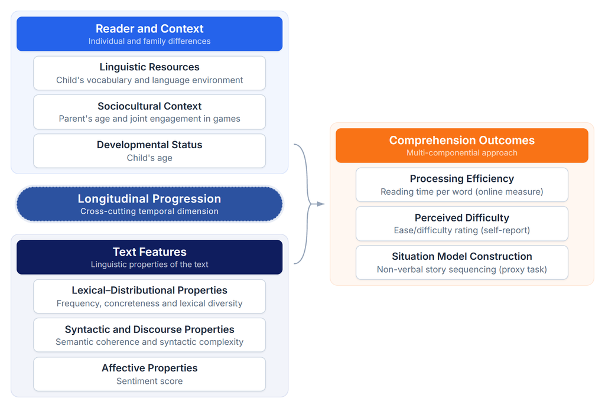

## 2.6 Analytic Plan

All confirmatory analyses will use Bayesian hierarchical models fitted with the `brms` package (Bürkner, 2017), which implements full Bayesian inference via Hamiltonian Monte Carlo (No-U-Turn Sampler). We adopt this framework in preference to null-hypothesis significance testing because our scientific questions concern the *magnitude* and *direction* of effects rather than their mere existence, the expected sample size confers effectively unlimited frequentist power that renders *p*-value thresholds uninformative, and a single unified framework avoids the family-wise error inflation that arises from conditional multi-stage testing. Prior distributions are specified to be genuinely informative; their motivation and the prior placed on each parameter class are set out under Prior Specification below.

For each pre-registered hypothesis we will report, unconditionally and regardless of outcome, the posterior mean and 95% highest-density interval (HDI) for the relevant parameter; the posterior probability that the parameter falls in the predicted direction, P($\beta$ < 0) or P($\beta$ > 0) as specified per hypothesis; and the proportion of the posterior that lies within a region of practical equivalence (ROPE) (Kruschke, 2018) defined as $|\beta| < 0.05$ on the standardised scale — the threshold below which we consider an effect too small to be educationally meaningful. If more than 95% of the posterior lies within the ROPE we conclude practical equivalence; if less than 5% lies within the ROPE we conclude the effect is practically meaningful. All five confirmatory hypotheses are evaluated under this framework simultaneously and unconditionally, with no first-stage filter. Four chains of 4,000 iterations each (2,000 warm-up) will be run, with $\hat{R}$ < 1.01 and effective sample size > 1,000 per parameter as convergence diagnostics.

### 2.6.1 Prior Specification

We specify genuinely informative, regularising priors. This departs from the diffuse or default priors common in applied work; the default `brms` prior on population-level coefficients, for instance, is an improper flat prior that imposes no regularisation (Bürkner, 2017). This choice is motivated on two grounds. First, priors that concentrate mass on plausible parameter values regularise the posterior geometry and thereby improve Hamiltonian Monte Carlo sampling — reducing divergent transitions, raising effective sample sizes, and shortening warm-up and total sampling time — an instance of the principle that computational difficulties usually signal an under-constrained model rather than a purely numerical obstacle (Betancourt, 2017; Gelman et al., 2020). For a maximal random-effects structure over many-levelled and partly sparse Child and Language groupings, this regularisation is also what makes a complex model estimable within a feasible time frame, and more informative priors are known to speed convergence in exactly such hierarchical, reading-time models (McElreath, 2020; Schad et al., 2021). Second, although the very large sample means the likelihood will dominate the posterior for the main effects (Lemoine, 2019), the priors still do real work in the sparsely populated parts of the design — small language strata, random slopes within child, and the higher-order interactions — where they guard against implausibly large estimates.

Because the predictors are standardised and reading time is log-transformed, the fixed-effect coefficients are interpretable on a per-standard-deviation scale, on which reading-research effects are modest: word frequency and predictability enter reading time approximately logarithmically and with small per-unit slopes (Shain et al., 2024), and the reading-speed–comprehension association is moderate (*r* ≈ .39–.48) (Sortkær et al., 2021). We therefore place Normal(0, 0.2) priors on the population-level main-effect coefficients and tighter Normal(0, 0.1) priors on the three critical interaction terms, which are expected to be smaller and for which direct effect-size evidence is sparser. Normal rather than Student’s *t* priors are used for these coefficients because their log-concave tails additionally aid sampling (Gelman et al., 2020). Because the five hypotheses are evaluated confirmatorily and unconditionally, every prior is centred at zero and symmetric: it regularises through its scale alone and does not encode the predicted direction, so the data remain free to disconfirm each hypothesis (Schad et al., 2021). Group-level standard deviations (for Child, Language, and the random slopes) receive half-Normal(0, 1) priors, as does the residual standard deviation; the random-effect correlation matrices receive LKJ($\eta$ = 2) priors, which place the mode at the identity matrix and gently discourage the near-perfect random-slope correlations that drive divergences in maximal models (Bürkner, 2017; Lewandowski et al., 2009). For the comprehension model, whose coefficients are on the logit scale, we use a Normal(0, 1.5) prior on the intercept — approximately uniform on the probability scale — and Normal(0, 0.5) priors on the standardised slopes, since a flat prior is not non-informative once transformed to a probability (Lemoine, 2019).

All priors will be examined with prior predictive simulations before any model is fitted to the data, and their influence will be quantified in a pre-registered prior-sensitivity analysis that compares them against the weakly informative alternatives (see Sensitivity Analyses), in line with recommended Bayesian-workflow practice (Schad et al., 2021; van de Schoot et al., 2021).

### 2.6.2 Sampling Plan and Inferential Sensitivity

Because the study analyses pre-existing observational data, the sampling plan is defined by the inclusion and exclusion criteria (see Participants) rather than by recruitment, and the analytic sample — first-time story readings nested within children, who are nested within languages — is expected to be very large: in its first six months the platform recorded over 2.4 million story sessions and more than 50,000 generated stories (Ratner et al., 2025). The exact analysable *N* is fixed by the pre-registered filters and is unknown until extraction. At this scale the binding constraint on inference is the precision of estimation and the *practical* magnitude of effects, rather than statistical power: even negligible effects attain conventional significance when *N* is in the millions (Gelman & Carlin, 2014). We therefore replace a conventional power analysis with a precision-based Bayesian design analysis organised around the region of practical equivalence (ROPE) and the highest-density-interval decision rule (Kruschke, 2018).

Prior to fitting any model to the real data, we will conduct a simulation-based design analysis. We will generate synthetic datasets that match the planned multilevel structure (children within languages), realistic per-child and per-language session counts, and a range of plausible effect sizes drawn from the priors and from the closest empirical estimates — including the reading-speed–ability association (*r* ≈ .39–.48) reported by Sortkær et al. (2021) and typical syntactic-complexity effects on children’s reading (*d* ≈ 0.2–0.5) — and will fit the confirmatory models (below) to each. For every focal parameter we will report the expected posterior width and the probability that its 95% HDI will fall determinately inside or outside the ROPE, that is, the probability of a conclusive practical-equivalence decision. This establishes a priori that, at the anticipated sample size, the design can return an informative answer to each hypothesis. The same simulation identifies the minimum analysable *N* at which a conclusive decision is reached with at least 90% probability for each parameter; if extraction yields fewer eligible observations for a given hypothesis — for example, within smaller language groups — that hypothesis will be flagged as insufficiently sensitive and interpreted descriptively rather than confirmatorily.

### 2.6.3 Outcome-Neutral Quality Checks and Positive Controls

To confirm that the data and the analysis pipeline can detect known effects before the focal hypotheses are evaluated, we pre-specify the following outcome-neutral checks, each independent of the critical interactions. First, as a validity check on the timing measure, total story reading time must increase with story word count; a strong positive association is a precondition for treating reading time as an index of reading effort, and its absence would indicate that recorded times do not reflect engagement with the text. Second, as a positive control on the feature pipeline, word frequency is the most robust and cross-linguistically replicable lexical predictor of reading time (Mézière et al., 2023; Norman et al., 2025; van Heuven et al., 2014); the frequency-bearing component must show the expected slowing of reading for lower-frequency words, and its failure would indicate that the multilingual feature-extraction pipeline is not capturing genuine lexical signal, rendering null results for the other text components uninterpretable. Third, the per-language distributions of reading time per word and of quiz accuracy will be screened for floor and ceiling effects and for adequate variance; an outcome lying at floor or ceiling for more than 90% of observations within a language will not be modelled in that language. Fourth, as a check on the meaning of the narration flag, reading time in narrated sessions should covary with the narrated audio duration of the story where that information is recoverable, confirming that the flag indexes a genuine change in the reading situation and quantifying the extent to which pace is externally set (informing the interpretation of the Narration × ChildAge effect). These checks are evaluated before the confirmatory models; where a check fails, the dependent confirmatory test is reported as uninterpretable rather than as evidence for or against the corresponding hypothesis.

### 2.6.4 Dimension Reduction via Principal Component Analysis

Before fitting any mixed-effects model, we will reduce the full set of text-level features to a smaller number of stable, interpretable components using PCA, following the approach of Crossley (2025). PCA is chosen over exploratory factor analysis because the goal is dimension reduction of observed stimulus properties rather than estimation of unobserved latent causes: there is no theoretical basis for claiming that a latent factor *causes* MTLD, dependency distance and connective density to co-vary, and treating them as reflective indicators of a latent construct would misrepresent the nature of computational linguistic indices (Crossley, 2025).

Prior to PCA, variables will pass through several pre-screening stages. Variables with more than 20% missing values in any language, near-zero variance (SD < 0.01 after within-language standardisation), or excessive zero inflation (more than 20% zero counts) will be excluded. Variables showing absolute skewness or excess kurtosis greater than 3 will also be removed (Crossley, 2025). Where two variables correlate at $r$ > .90, we will retain the variable with stronger theoretical motivation, better cross-linguistic availability, lower missingness, or clearer interpretability. This selection will not consult the variable’s correlation with the outcome, preventing outcome information from leaking into feature construction.

All retained variables will be $z$-scored within language before PCA, removing between-language scale differences while preserving within-language variation. The primary analysis pools all language-standardised variables into a single PCA conducted in R using the `psych` package (Revelle, 2023), after verifying the Kaiser–Meyer–Olkin (KMO) measure of sampling adequacy (individual KMO > .50; overall KMO > .60) and Bartlett’s test of sphericity. We use oblique rotation (promax, $\kappa$ = 4) rather than varimax, because linguistic features are naturally correlated and an orthogonality assumption is theoretically unjustified (Biber, 1988; Crossley, 2025). Components will be retained based on three jointly applied criteria: parallel analysis (Horn, 1965), which retains components whose eigenvalues exceed the 95th percentile from 10,000 matched random data structures; scree-plot inspection; and interpretability, with a component accepted only if the pattern matrix admits a coherent reading-theoretic interpretation. Variables with absolute pattern loadings below .30 will not be attributed to any component. Weighted regression factor scores for each retained component will then be computed per story and will serve as text-level predictors in the confirmatory models below. The full pattern matrix (all loadings ≥ .15), component-score intercorrelations, proportion of variance per component, and per-variable KMO values will be reported in a supplementary table, with each component named based on its highest-loading variables and theoretical interpretation.

### 2.6.5 Confirmatory Models

The primary outcome model predicts log-transformed reading time per word — log transformation normalises the positively skewed distribution, with posterior predictive fit verified via `pp_check` plots — from the retained text-feature PC scores, child age, narration condition, and three pre-registered critical interactions: the syntactic-structural component (SyntaxPC) × ChildAge, the semantic/coherence component (CoherencePC) × ChildAge, and Narration × ChildAge. The random-effects structure follows a maximal justified specification, with random intercepts for Child and Language and random slopes for the key PC components within Child (e.g., `(1 + SyntaxPC + CoherencePC | Child)`). Observations with standardised residuals exceeding ±3 *SD* based on posterior predictive draws will be flagged and removed, with both the full-data and trimmed models reported.

A second confirmatory model predicts comprehension accuracy derived from in-app quiz responses. If accuracy data are binary (correct/incorrect per question), we will use a Bernoulli model with a logit link; if they are continuous (e.g., proportion correct per story), we will use a Beta regression. The fixed-effects and random-effects structure mirrors the reading-time model.

### 2.6.6 Convergence and Multicollinearity

A random intercept for *Language* will be included in all models to account for between-language variability and enable partial pooling. If the maximal random-effects structure fails to converge — assessed via $\hat{R}$ and divergent transition diagnostics — we will simplify by removing the random slope with the smallest posterior variance and iterating until convergence is achieved, reporting all simplification steps. Residual multicollinearity among the retained PC scores will be assessed using variance inflation factors (VIF) on the design matrix after the dimension-reduction step; if any VIF exceeds 5, the component with the lowest theoretical relevance for the confirmatory hypotheses will be removed.

### 2.6.7 Model Comparison

We will compare nested models — the full model against a version excluding each interaction of interest — using leave-one-out cross-validation (LOO-CV; `loo` package), reporting the expected log pointwise predictive density difference (ELPD$_\text{LOO}$) and its standard error. LOO-CV is preferred over likelihood-ratio tests because it requires no asymptotic approximations and is well-calibrated within the Bayesian framework adopted here.

### 2.6.8 Minimum Effect Size and ROPE Calibration

ROPE bounds are informed by standardised effect sizes from the closest available prior studies: Sortkær et al. (2021) reported $r$ ≈ .39–.48 for reading-speed effects, and syntactic complexity effects on children’s reading times in eye-tracking studies are typically in the range $d$ = 0.2–0.5. A standardised $\beta$ of 0.05 is therefore conservatively below the range of effects the existing literature considers educationally meaningful. Sensitivity analyses varying the ROPE bound to ±0.03 and ±0.10 will assess the robustness of practical-equivalence conclusions.

### 2.6.9 Sensitivity Analyses

Seven pre-registered sensitivity analyses will assess the robustness of the main findings. The primary models will first be re-fitted without the outlier exclusion criteria to establish whether winsorisation and residual trimming drive any substantive conclusions. They will then be restricted to the five largest language groups to evaluate cross-linguistic generalisability independently of less-represented languages. A third analysis will recode child age as a categorical variable (7, 8, 9, or 10 years) to test whether the linear-age assumption is adequate. A fourth will vary the ROPE bounds to ±0.03 and ±0.10 as described above. In a fifth analysis, the confirmatory models will be re-estimated using sparse PCA scores — obtained via the R package `sparsepca`, with sparsity regularisation selected by cross-validation — to assess whether structurally simpler components with fewer non-zero loadings alter the substantive pattern of results. Language-specific PCAs will replace the pooled solution, with one PCA fitted per language, to test whether the cross-lingual feature space adequately represents within-language variation. Finally, a prior-sensitivity analysis will re-fit the confirmatory models under the previously specified weakly informative priors (Student’s *t*(3, 0, 2.5) on the fixed effects) to confirm that the substantive conclusions are driven by the data rather than by the informative priors (van de Schoot et al., 2021).

### 2.6.10 Supplementary Frequentist Models

To facilitate comparison with prior literature and to assist readers unfamiliar with Bayesian inference, fixed-effect point estimates, standard errors, and confidence intervals from a maximum-likelihood linear mixed model (LMM; fitted with `lme4`/`lmerTest`, identical random-effects structure) will be reported in a supplementary table. These results are descriptive only and carry no confirmatory weight; all hypothesis evaluation is conducted solely via the Bayesian framework described above.

# 3 Hypotheses

Our hypotheses are directional and each maps onto a specific fixed-effect or interaction term in the confirmatory models described above. Following the PCA procedure described in the Analytic Plan (see Dimension Reduction via Principal Component Analysis), hypotheses about text-level features are stated in terms of the PC component families expected to carry the relevant variance. The syntactic-structural component is referred to as SyntaxPC; the semantic/coherence component as CoherencePC; and the lexical-distributional component as LexDistPC. Because exact component names will be assigned post-hoc from the pattern matrix, each directional prediction is conditional on a component with the expected feature profile emerging from the PCA; if a relevant component does not emerge, the corresponding hypothesis will be reported as untestable. Because reading time is the outcome and child age is mean-centred (so that lower values denote younger children), the sign of an interaction term depends on the direction of the corresponding main effect: a moderation in which an effect is *stronger for younger children* appears as a negative interaction when the main effect lengthens reading time (Hypothesis 2) but as a positive interaction when the main effect shortens it (Hypothesis 3).

First, we predict that text-level features predict reading time: stories scoring higher on syntactic and lexical difficulty — with longer dependency distances, less frequent words, higher lexical diversity and lower coherence — should be associated with longer reading times per word. We expect main effects of SyntaxPC and LexDistPC in the direction of longer reading times, and a main effect of CoherencePC in the direction of shorter reading times.

Second, we predict that syntactic complexity effects are moderated by child age (Delage & Frauenfelder, 2019; Roque-Gutierrez & Ibbotson, 2023). Because younger children’s working memory capacity is less developed, texts with longer syntactic dependencies should slow their reading more steeply than for older children. We expect a negative SyntaxPC × ChildAge interaction on reading time (i.e., the slowing effect of the syntactic-structural component diminishes with age).

Third, we predict that discourse coherence benefits younger children more than older children. Higher coherence reduces the inferential burden on the reader (Crossley et al., 2019; Graesser et al., 2014), and this support should be especially valuable for younger children who have less background knowledge and weaker inference-generation skills. We expect a positive CoherencePC × ChildAge interaction on reading time (i.e., the reading-time-reducing effect of the semantic/coherence component is strongest for the youngest children and weakens — becoming less negative — as age increases).

Fourth, we predict that narration benefits younger children more than older children. The read-aloud narration feature, when enabled, should yield a larger improvement in reading speed for younger children, who are still developing decoding fluency, than for older children. We expect a positive Narration × ChildAge interaction on reading time — the reading-time reduction afforded by narration being largest for the youngest children and weakening with age — and test this interaction accordingly.

Fifth, we predict that app-derived reading time correlates with comprehension. Average reading speed, as a proxy for fluency, should relate positively to comprehension accuracy — consistent with the findings of Sortkær et al. (2021). We will test this by predicting quiz-derived comprehension accuracy from mean reading rate.

## 3.1 Study Design Table

Table 4: Study design table linking research questions, hypotheses, statistical tests, and the interpretation of possible outcomes. All confirmatory tests use the Bayesian multilevel models and the ROPE/HDI decision rule set out in the Analytic Plan; sampling adequacy for each test is established by the design analysis (see Sampling Plan and Inferential Sensitivity), and every test is conditional on the outcome-neutral quality checks.

[output not shown]

## 3.2 Exploratory Analyses

Beyond the confirmatory tests above, we plan several analyses that are explicitly designated as exploratory and will be reported separately.

For interactions showing a directional posterior probability > 0.95 in the confirmatory models, we will probe the pattern of results using simple slopes analysis at ±1 *SD* of the moderator variable. In the Bayesian framework this involves computing marginal posterior distributions at specified covariate values using `emmeans` or `marginaleffects`, providing posterior means and HDIs at each level of the moderator.

Finally, we will explore whether text complexity features show non-linear (quadratic) relationships with reading time, which would suggest diminishing or accelerating effects at extreme levels of complexity.

All exploratory results will be clearly labelled as such in the manuscript, and we will not draw confirmatory conclusions from these analyses.

# Declarations

# Appendix: Per-Language Norm Sources

For the lexicon-dependent measures (frequency, age of acquisition, concreteness/imageability, valence/arousal, and the LIWC word-category counts), the validated native norms listed in Table 5 will be used wherever they exist. Every other language–measure combination defaults to the cross-language resource specified in Table 3 — `wordfreq` for frequency (Speer, 2022), the NRC VAD lexicon for valence and arousal (Mohammad, 2018), and the 25-language set of Łuniewska et al. (2016) for age of acquisition — or, where no validated norm is available, is recorded as missing and removed by the pre-screening rule (see Analytic Plan). Native frequency norms are additionally used to validate the `wordfreq` estimates. The language-general measures (lexical diversity, all syntactic indices, coherence, and surprisal) are computed identically across languages and are not repeated here.

Table 5: Validated native norm sources by language for the lexicon-dependent measures. Entries not listed use the cross-language defaults described in the text (`wordfreq` for frequency, the NRC VAD lexicon for valence and arousal, and the Łuniewska et al. (2016) set for age of acquisition) or are treated as missing under the pre-screening rule.

[output not shown]

The exact set of generation languages, and hence the rows of this appendix, will be fixed from the platform metadata at data extraction (see Participants).

## 4 References

Alonso, M. Á., Fernández, Á., & Díez, E. (2015). Subjective age-of-acquisition norms for 7,039 Spanish words. *Behavior Research Methods*, *47*(1), 268–274. https://doi.org/10.3758/s13428-014-0454-2

Altamura, L., Vargas, C., Naumann, J., & Salmerón, L. (2025). How digital reading habits shape reading motivation and comprehension over time: Longitudinal associations in primary school. *Developmental Psychology*. https://doi.org/10.1037/dev0002094

Babayiğit, S., Hitch, G. J., Kandru-Pothineni, S., Clarke, A., & Warmington, M. (2022). Vocabulary limitations undermine bilingual children’s reading comprehension despite bilingual cognitive strengths. *Reading and Writing*, *35*(7), 1651–1673. https://doi.org/10.1007/s11145-021-10240-8

Bernabeu, P. (2022). *Language and sensorimotor simulation in conceptual processing: Multilevel analysis and statistical power* [PhD thesis, Lancaster University]. https://doi.org/10.17635/LANCASTER/THESIS/1795

Berzak, Y., Malmaud, J., Shubi, O., Meiri, Y., Lion, E., & Levy, R. (2025). OneStop: A 360-Participant English Eye Tracking Dataset with Different Reading Regimes. *Scientific Data*, *12*(1), 1995. https://doi.org/10.1038/s41597-025-06272-2

Betancourt, M. (2017). *A conceptual introduction to Hamiltonian Monte Carlo*. https://doi.org/10.48550/arXiv.1701.02434

Biber, D. (1988). *Variation across speech and writing* (1st ed.). Cambridge University Press. https://doi.org/10.1017/CBO9780511621024

Booton, S. A., Hodgkiss, A., & Murphy, V. A. (2023). The impact of mobile application features on children’s language and literacy learning: A systematic review. *Computer Assisted Language Learning*, *36*(3), 400–429. https://doi.org/10.1080/09588221.2021.1930057

Boyd, R. L., Ashokkumar, A., Seraj, S., & Pennebaker, J. W. (2022). *The development and psychometric properties of LIWC-22*. University of Texas at Austin. https://www.liwc.app/static/documents/LIWC-22%20Manual%20-%20Development%20and%20Psychometrics.pdf

Brysbaert, M., Buchmeier, M., Conrad, M., Jacobs, A. M., Bölte, J., & Böhl, A. (2011). The word frequency effect: A review of recent developments and implications for the choice of frequency estimates in German (SUBTLEX-DE). *Experimental Psychology*, *58*(5), 412–424. https://doi.org/10.1027/1618-3169/a000123

Brysbaert, M., Mandera, P., McCormick, S. F., & Keuleers, E. (2019). Word prevalence norms for 62,000 English lemmas. *Behavior Research Methods*, *51*(2), 467–479. https://doi.org/10.3758/s13428-018-1077-9

Brysbaert, M., Stevens, M., De Deyne, S., Voorspoels, W., & Storms, G. (2014). Norms of age of acquisition and concreteness for 30,000 Dutch words. *Acta Psychologica*, *150*, 80–84. https://doi.org/10.1016/j.actpsy.2014.04.010

Brysbaert, M., Warriner, A. B., & Kuperman, V. (2014). Concreteness ratings for 40 thousand generally known English word lemmas. *Behavior Research Methods*, *46*(3), 904–911. https://doi.org/10.3758/s13428-013-0403-5

Bürkner, P.-C. (2017). brms: An R package for Bayesian multilevel models using Stan. *Journal of Statistical Software*, *80*, 1–28. https://doi.org/10.18637/jss.v080.i01

Cai, Q., & Brysbaert, M. (2010). SUBTLEX-CH: Chinese word and character frequencies based on film subtitles. *PLOS ONE*, *5*(6), e10729. https://doi.org/10.1371/journal.pone.0010729

Cain, K., & Oakhill, J. (2014). Reading comprehension and vocabulary: Is vocabulary more important for some aspects of comprehension? *L’Année Psychologique*, *114*(4), 647–662. https://doi.org/10.3917/anpsy.144.0647

Chang, I. (2020). Influences of executive function, language comprehension, and fluency on young children’s reading comprehension. *Journal of Early Childhood Research*, *18*(1), 44–57. https://doi.org/10.1177/1476718X19875768

Chang, T. A., Arnett, C., Tu, Z., & Bergen, B. K. (2024). *Goldfish: Monolingual language models for 350 languages*. https://doi.org/10.48550/arXiv.2408.10441

Chatzopoulos, A., Karaflis, A., Kalogiannakis, M., Tzerachoglou, A., Cheirchanteri, G., Sfyroera, E., & Sklavounou, E.-O. (2023). Evaluation of Google Play educational apps for early childhood education. *Advances in Mobile Learning Educational Research*, *3*(2), 770–778. https://doi.org/10.25082/AMLER.2023.02.004

Chuang, C., & Jamiat, N. (2023). A systematic review on the effectiveness of children’s interactive reading applications for promoting their emergent literacy in the multimedia context. *Contemporary Educational Technology*, *15*(2), ep412. https://doi.org/10.30935/cedtech/12941

Crepaldi, D., Amenta, S., Mandera, P., Keuleers, E., & Brysbaert, M. (2015). SUBTLEX-IT: Subtitle-based word frequency estimates for Italian. *Proceedings of the Annual Meeting of the Italian Association for Experimental Psychology (AIP)*.

Crossley, S. A. (2025). Developing linguistic constructs of text readability using natural language processing. *Scientific Studies of Reading*, *29*(2), 138–160. https://doi.org/10.1080/10888438.2024.2422365

Crossley, S. A., Kyle, K., & Dascalu, M. (2019). The Tool for the Automatic Analysis of Cohesion 2.0: Integrating semantic similarity and text overlap. *Behavior Research Methods*, *51*(1), 14–27. https://doi.org/10.3758/s13428-018-1142-4

Crossley, S. A., Skalicky, S., Berger, C., & Heidari, A. (2023). Assessing readability formulas in the wild. In M. Dascalu, P. Marti, & F. Pozzi (Eds.), *Polyphonic Construction of Smart Learning Ecosystems* (pp. 91–101). Springer Nature. https://doi.org/10.1007/978-981-19-5240-1_6

Cui, N., Wang, Y., Luo, J., & Wu, Y. (2024). The role of executive functions in 9‐ to 12‐year‐old children’s sentence processing: An eye‐movement study. *Journal of Research in Reading*, *47*(2), 201–219. https://doi.org/10.1111/1467-9817.12449

Delage, H., & Frauenfelder, U. H. (2019). Syntax and working memory in typically-developing children: Focus on syntactic complexity. *Language, Interaction and Acquisition*, *10*(2), 141–176. https://doi.org/10.1075/lia.18013.del

Della Rosa, P. A., Catricalà, E., Vigliocco, G., & Cappa, S. F. (2010). Beyond the abstract-concrete dichotomy: Mode of acquisition, concreteness, imageability, familiarity, age of acquisition, context availability, and abstractness norms for a set of 417 Italian words. *Behavior Research Methods*, *42*(4), 1042–1048. https://doi.org/10.3758/BRM.42.4.1042

Desrochers, A., & Thompson, G. L. (2009). Subjective frequency and imageability ratings for 3,600 French nouns. *Behavior Research Methods*, *41*(2), 546–557. https://doi.org/10.3758/BRM.41.2.546

Duchon, A., Perea, M., Sebastián-Gallés, N., Martí, A., & Carreiras, M. (2013). EsPal: One-stop shopping for Spanish word properties. *Behavior Research Methods*, *45*(4), 1246–1258. https://doi.org/10.3758/s13428-013-0326-1

Duff, D., & Brydon, M. (2020). Estimates of individual differences in vocabulary size in English: How many words are needed to “close the vocabulary gap”? *Journal of Research in Reading*, *43*(4), 454–481. https://doi.org/10.1111/1467-9817.12322

Feng, F., Yang, Y., Cer, D., Arivazhagan, N., & Wang, W. (2022). Language-agnostic BERT sentence embedding. *Proceedings of the 60th Annual Meeting of the Association for Computational Linguistics (Volume 1: Long Papers)*, 878–891. https://doi.org/10.18653/v1/2022.acl-long.62

Ferrand, L., Bonin, P., Méot, A., Augustinova, M., New, B., Pallier, C., & Brysbaert, M. (2008). Age-of-acquisition and subjective frequency estimates for all generally known monosyllabic French words and their relation with other psycholinguistic variables. *Behavior Research Methods*, *40*(4), 1049–1054. https://doi.org/10.3758/BRM.40.4.1049

Fredrick, D. R., & Craven, L. (2025). Lexical diversity, syntactic complexity, and readability: A corpus-based analysis of ChatGPT and L2 student essays. *Frontiers in Education*, *10*. https://doi.org/10.3389/feduc.2025.1616935

Furenes, M. I., Kucirkova, N., & Bus, A. G. (2021). A comparison of children’s reading on paper versus screen: A meta-analysis. *Review of Educational Research*, *91*(4), 483–517. https://doi.org/10.3102/0034654321998074

Furlong, L., Serry, T., Erickson, S., Lefort, M., Gath, M., & Morris, M. (2025). Finding the needle in the haystack: A quality appraisal of mobile applications for foundational literacy skills. *Early Childhood Education Journal*. https://doi.org/10.1007/s10643-025-02066-8

Gelman, A., & Carlin, J. (2014). Beyond power calculations: Assessing Type S (sign) and Type M (magnitude) errors. *Perspectives on Psychological Science*, *9*(6), 641–651. https://doi.org/10.1177/1745691614551642

Gelman, A., Vehtari, A., Simpson, D., Carpenter, B., Margossian, C. C., Yao, Y., Kennedy, L., Gabry, J., Bürkner, P.-C., & Modrák, M. (2020). *Bayesian workflow*. https://doi.org/10.48550/arXiv.2011.01808

Goldman, S. R. (2024). Reading is complex: Implications for research and practice. *Educational Psychologist*, *59*(4), 315–325. https://doi.org/10.1080/00461520.2024.2418062

Graesser, A. C., McNamara, D. S., Cai, Z., Conley, M., Li, H., & Pennebaker, J. (2014). Coh-metrix measures text characteristics at multiple levels of language and discourse. *The Elementary School Journal*, *115*(2), 210–229. https://doi.org/10.1086/678293

Gu, C., Nastase, S. A., Zada, Z., & Li, P. (2025). Reading comprehension in L1 and L2 readers: Neurocomputational mechanisms revealed through large language models. *Npj Science of Learning*, *10*(1), 46. https://doi.org/10.1038/s41539-025-00337-y

Hahn, M., & Keller, F. (2023). Modeling task effects in human reading with neural network-based attention. *Cognition*, *230*, 105289. https://doi.org/10.1016/j.cognition.2022.105289

Hattan, C., & Kendeou, P. (2024). Expanding the science of reading: Contributions from educational psychology. *Educational Psychologist*, *59*(4), 217–232. https://doi.org/10.1080/00461520.2024.2418048

Horn, J. L. (1965). A rationale and test for the number of factors in factor analysis. *Psychometrika*, *30*(2), 179–185. https://doi.org/10.1007/BF02289447

Hosseini, E. A., Schrimpf, M., Zhang, Y., Bowman, S., Zaslavsky, N., & Fedorenko, E. (2024). Artificial neural network language models predict human brain responses to language even after a developmentally realistic amount of training. *Neurobiology of Language*, *5*(1), 43–63. https://doi.org/10.1162/nol_a_00137

Hsiao, Y., & Nation, K. (2018). Semantic diversity, frequency and the development of lexical quality in children’s word reading. *Journal of Memory and Language*, *103*, 114–126. https://doi.org/10.1016/j.jml.2018.08.005

Imbir, K. K. (2016). Affective norms for 4900 Polish words reload (ANPW_R): Assessments for valence, arousal, dominance, origin, significance, concreteness, imageability and age of acquisition. *Frontiers in Psychology*, *7*, 1081. https://doi.org/10.3389/fpsyg.2016.01081

Kaup, B., Günther, F., & Dudschig, C. (2025). The interplay of modal and amodal processes in language comprehension at the word level and beyond. In *Psychology of Learning and Motivation*. Academic Press. https://doi.org/10.1016/bs.plm.2025.08.001

Keuleers, E., Brysbaert, M., & New, B. (2010). SUBTLEX-NL: A new measure for Dutch word frequency based on film subtitles. *Behavior Research Methods*, *42*(3), 643–650. https://doi.org/10.3758/BRM.42.3.643

Köper, M., & Schulte im Walde, S. (2016). Automatically generated affective norms of abstractness, arousal, imageability and valence for 350 000 German lemmas. *Proceedings of the Tenth International Conference on Language Resources and Evaluation (LREC’16)*, 2595–2598. https://aclanthology.org/L16-1413/

Korochkina, M., Marelli, M., Brysbaert, M., & Rastle, K. (2024). The Children and Young People’s Books Lexicon (CYP-LEX): A large-scale lexical database of books read by children and young people in the United Kingdom. *Quarterly Journal of Experimental Psychology*, *77*(12), 2418–2438. https://doi.org/10.1177/17470218241229694

Kruschke, J. K. (2018). Rejecting or accepting parameter values in Bayesian estimation. *Advances in Methods and Practices in Psychological Science*, *1*(2), 270–280. https://doi.org/10.1177/2515245918771304

Kuperman, V., Stadthagen-Gonzalez, H., & Brysbaert, M. (2012). Age-of-acquisition ratings for 30,000 English words. *Behavior Research Methods*, *44*(4), 978–990. https://doi.org/10.3758/s13428-012-0210-4

Lemoine, N. P. (2019). Moving beyond noninformative priors: Why and how to choose weakly informative priors in Bayesian analyses. *Oikos*, *128*(7), 912–928. https://doi.org/10.1111/oik.05985

Lervåg, A., & Aukrust, V. G. (2010). Vocabulary knowledge is a critical determinant of the difference in reading comprehension growth between first and second language learners. *Journal of Child Psychology and Psychiatry*, *51*(5), 612–620. https://doi.org/10.1111/j.1469-7610.2009.02185.x

Lewandowski, D., Kurowicka, D., & Joe, H. (2009). Generating random correlation matrices based on vines and extended onion method. *Journal of Multivariate Analysis*, *100*(9), 1989–2001. https://doi.org/10.1016/j.jmva.2009.04.008

Li, C., Wang, X., & Qian, L. (2025). Exploring syntactic complexity and text readability in an ELT textbook series for Chinese English majors. *Sage Open*, *15*(1), 21582440251323619. https://doi.org/10.1177/21582440251323619

Łuniewska, M., Haman, E., Armon-Lotem, S., Etenkowski, B., et al. (2016). Ratings of age of acquisition of 299 words across 25 languages: Is there a cross-linguistic order of words? *Behavior Research Methods*, *48*(3), 1154–1177. https://doi.org/10.3758/s13428-015-0636-6

Magnabosco, F., & Hauk, O. (2024). An eye on semantics: A study on the influence of concreteness and predictability on early fixation durations. *Language, Cognition and Neuroscience*, *39*(3), 302–316. https://doi.org/10.1080/23273798.2023.2274558

Mandera, P., Keuleers, E., Wodniecka, Z., & Brysbaert, M. (2015). SUBTLEX-PL: Subtitle-based word frequency estimates for Polish. *Behavior Research Methods*, *47*(2), 471–483. https://doi.org/10.3758/s13428-014-0489-4

Marjokorpi, J., & van Rijt, J. (2025). Grammatical understanding predicts reading comprehension in secondary-level students: Insights from a Finnish national survey. *Language and Education*, *39*(4), 924–943. https://doi.org/10.1080/09500782.2024.2376280

Marneffe, M.-C. de, Manning, C. D., Nivre, J., & Zeman, D. (2021). Universal dependencies. *Computational Linguistics*, *47*(2), 255–308. https://doi.org/10.1162/coli_a_00402

McCarthy, P. M., & Jarvis, S. (2010). MTLD, vocd-D, and HD-D: A validation study of sophisticated approaches to lexical diversity assessment. *Behavior Research Methods*, *42*(2), 381–392. https://doi.org/10.3758/BRM.42.2.381

McElreath, R. (2020). *Statistical rethinking: A Bayesian course with examples in R and Stan* (2nd ed.). Chapman; Hall/CRC. https://doi.org/10.1201/9780429029608

Mézière, D. C., Yu, L., Reichle, E. D., von der Malsburg, T., & McArthur, G. (2023). Using eye-tracking measures to predict reading comprehension. *Reading Research Quarterly*, *58*(3), 425–449. https://doi.org/10.1002/rrq.498

Mohammad, S. (2018). Obtaining reliable human ratings of valence, arousal, and dominance for 20,000 English words. *Proceedings of the 56th Annual Meeting of the Association for Computational Linguistics (Volume 1: Long Papers)*, 174–184. https://doi.org/10.18653/v1/P18-1017

Monaghan, P. (2023). Literacy and early language development: Insights from computational modelling. *Journal of Child Language*, *50*(6), 1394–1410. https://doi.org/10.1017/S0305000923000193

Monnier, C., & Syssau, A. (2014). Affective norms for French words (FAN). *Behavior Research Methods*, *46*(4), 1128–1137. https://doi.org/10.3758/s13428-013-0431-1

Monnier, C., & Syssau, A. (2017). Affective norms for 720 French words rated by children and adolescents (FANchild). *Behavior Research Methods*, *49*(5), 1882–1893. https://doi.org/10.3758/s13428-016-0831-0

Montefinese, M., Ambrosini, E., Fairfield, B., & Mammarella, N. (2014). The adaptation of the Affective Norms for English Words (ANEW) for Italian. *Behavior Research Methods*, *46*(3), 887–903. https://doi.org/10.3758/s13428-013-0405-3

Moors, A., De Houwer, J., Hermans, D., Wanmaker, S., Schie, K. van, Van Harmelen, A.-L., De Schryver, M., De Winne, J., & Brysbaert, M. (2013). Norms of valence, arousal, dominance, and age of acquisition for 4,300 Dutch words. *Behavior Research Methods*, *45*(1), 169–177. https://doi.org/10.3758/s13428-012-0243-8

Muraki, E. J., Reggin, L. D., Feddema, C. Y., & Pexman, P. M. (2025). The development of abstract word meanings. *Journal of Child Language*, *52*(1), 195–207. https://doi.org/10.1017/S0305000923000569

Nation, K. (2019). Children’s reading difficulties, language, and reflections on the simple view of reading. *Australian Journal of Learning Difficulties*, *24*(1), 47–73. https://doi.org/10.1080/19404158.2019.1609272

New, B., Pallier, C., Ferrand, L., & Matos, R. (2001). Une base de données lexicales du français contemporain sur internet: LEXIQUE. *L’Année Psychologique*, *101*(3), 447–462. https://doi.org/10.3406/psy.2001.1341

Nielsen, J. L., Christensen, R. V., & Poulsen, M. (2025). Syntactic comprehension—a separate source of individual variance in middle‐school children’s reading comprehension. *Reading Research Quarterly*, *60*(2), e70003. https://doi.org/10.1002/rrq.70003

Norman, R., Taylor, J. S. H., & Rodd, J. M. (2025). The effects of contextual diversity on lexical processing: A scoping review. *Psychonomic Bulletin & Review*, *32*(6), 2763–2806. https://doi.org/10.3758/s13423-025-02761-y

Pickren, S. E., Stacy, M., Tufo, S. N. D., Spencer, M., & Cutting, L. E. (2022). The contribution of text characteristics to reading comprehension: Investigating the influence of text emotionality. *Reading Research Quarterly*, *57*(2), 649–667. https://doi.org/10.1002/rrq.431

Qi, P., Zhang, Y., Zhang, Y., Bolton, J., & Manning, C. D. (2020). Stanza: A Python natural language processing toolkit for many human languages. *Proceedings of the 58th Annual Meeting of the Association for Computational Linguistics: System Demonstrations*, 101–108. https://doi.org/10.18653/v1/2020.acl-demos.14

Ratner, S., Ong, C., Mathers, S., & Murphy, V. A. (2025). “Did a robot write that?”: AI-generated digital storybooks. *ELT Journal*, ccaf034. https://doi.org/10.1093/elt/ccaf034

Revelle, W. (2023). *Psych: Procedures for psychological, psychometric, and personality research* [Manual]. Northwestern University. https://CRAN.R-project.org/package=psych

Roque-Gutierrez, E., & Ibbotson, P. (2023). Working memory training improves children’s syntactic ability but not vice versa: A randomized control trial. *Journal of Experimental Child Psychology*, *227*, 105593. https://doi.org/10.1016/j.jecp.2022.105593

Schad, D. J., Betancourt, M., & Vasishth, S. (2021). Toward a principled Bayesian workflow in cognitive science. *Psychological Methods*, *26*(1), 103–126. https://doi.org/10.1037/met0000275

Seidenberg, M. S., & MacDonald, M. C. (2018). The impact of language experience on language and reading: A statistical learning approach. *Topics in Language Disorders*, *38*(1), 66–83. https://doi.org/10.1097/TLD.0000000000000144

Shain, C., Meister, C., Pimentel, T., Cotterell, R., & Levy, R. (2024). Large-scale evidence for logarithmic effects of word predictability on reading time. *Proceedings of the National Academy of Sciences*, *121*(10), e2307876121. https://doi.org/10.1073/pnas.2307876121

Soares, A. P., Comesaña, M., Pinheiro, A. P., Simões, A., & Frade, C. S. (2012). The adaptation of the Affective Norms for English Words (ANEW) for European Portuguese. *Behavior Research Methods*, *44*(1), 256–269. https://doi.org/10.3758/s13428-011-0131-7

Soares, A. P., Costa, A. S., Machado, J., Comesaña, M., & Oliveira, H. M. (2017). The Minho Word Pool: Norms for imageability, concreteness, and subjective frequency for 3,800 Portuguese words. *Behavior Research Methods*, *49*(3), 1065–1081. https://doi.org/10.3758/s13428-016-0767-4

Sortkær, B., Smith, E., Reimer, D., Oehmcke, S., & Andersen, I. G. (2021). Both sides of the story: Comparing student-level data on reading performance from administrative registers to application generated data from a reading app. *EPJ Data Science*, *10*(1), 44. https://doi.org/10.1140/epjds/s13688-021-00300-y

Speer, R. (2022). *Wordfreq: Access a database of word frequencies in various natural languages* (Version 3.0.2) [Computer software]. https://github.com/rspeer/wordfreq

Stadthagen-González, H., Imbault, C., Pérez Sánchez, M. A., & Brysbaert, M. (2017). Norms of valence and arousal for 14,031 Spanish words. *Behavior Research Methods*, *49*(1), 111–123. https://doi.org/10.3758/s13428-015-0700-2

Tang, K. (2012). *A 61 million word corpus of Brazilian Portuguese film subtitles as a resource for linguistic research (SUBTLEX-PT-BR)* (No. 24). UCL Working Papers in Linguistics. https://www.kevintang.org/Tools.html

van de Schoot, R., Depaoli, S., King, R., Kramer, B., Märtens, K., Tadesse, M. G., Vannucci, M., Gelman, A., Veen, D., Willemsen, J., & Yau, C. (2021). Bayesian statistics and modelling. *Nature Reviews Methods Primers*, *1*(1), 1. https://doi.org/10.1038/s43586-020-00001-2

Van Den Bosch, L. J., Segers, E., & Verhoeven, L. (2019). The role of linguistic diversity in the prediction of early reading comprehension: A quantile regression approach. *Scientific Studies of Reading*, *23*(3), 203–219. https://doi.org/10.1080/10888438.2018.1509864

van Heuven, W. J. B., Mandera, P., Keuleers, E., & Brysbaert, M. (2014). Subtlex-UK: A new and improved word frequency database for British English. *Quarterly Journal of Experimental Psychology*, *67*(6), 1176–1190. https://doi.org/10.1080/17470218.2013.850521

Võ, M. L.-H., Conrad, M., Kuchinke, L., Urton, K., Hofmann, M. J., & Jacobs, A. M. (2009). The Berlin Affective Word List Reloaded (BAWL-R). *Behavior Research Methods*, *41*(2), 534–538. https://doi.org/10.3758/BRM.41.2.534

Wang, Z., Liu, M., & Liu, K. (2024). Utilizing machine learning techniques for classifying translated and non-translated corporate annual reports. *Applied Artificial Intelligence*, *38*(1), 2340393. https://doi.org/10.1080/08839514.2024.2340393

Warriner, A. B., Kuperman, V., & Brysbaert, M. (2013). Norms of valence, arousal, and dominance for 13,915 English lemmas. *Behavior Research Methods*, *45*(4), 1191–1207. https://doi.org/10.3758/s13428-012-0314-x

Yu, L.-C., Lee, L.-H., Hao, S., Wang, J., He, Y., Hu, J., Lai, K. R., & Zhang, X. (2016). Building Chinese affective resources in valence-arousal dimensions. *Proceedings of the 2016 Conference of the North American Chapter of the Association for Computational Linguistics: Human Language Technologies*, 540–545. https://doi.org/10.18653/v1/N16-1066